# Statistical Analysis of Ecological Data in R

Mohan Bi & Anika Lehmann

2025-04-24

# 0. Installation von R und RStudio

## Schritt 1: R herunterladen und installieren️

1. Gehe zur offiziellen **R-Download-Seite**:  
   https://cran.r-project.org/
2. Wähle dein Betriebssystem:
   - **Windows**: Klicke auf **„Download R for Windows“** → **„base“** → Lade die neueste `.exe`-Datei herunter.
   - **Mac**: Klicke auf **„Download R for macOS“** und lade das passende Installationspaket herunter.
   - **Linux**: Folge den Anweisungen entsprechend deiner Distribution.
3. Führe die heruntergeladene Datei aus und folge den Installationsanweisungen.

## Schritt 2: RStudio herunterladen und installieren

1. Gehe zur **RStudio-Download-Seite**:  
   https://posit.co/download/rstudio-desktop/
2. Lade die **kostenlose RStudio Desktop-Version** für dein Betriebssystem herunter.
3. Führe das Installationsprogramm aus und folge den Anweisungen zur Einrichtung.

# 1. Einführung

Eine Gruppe von Ökolog*innen untersucht Faktoren, die die Biomasseproduktion in einem bestimmten Grasland-Ökosystem beeinflussen.  
Sie sammeln Daten zu verschiedenen Einflussfaktoren, darunter die Schmetterlingspopulation, Sonnenflecken, der pH-Wert des Bodens und die Biomasseproduktion über einen bestimmten Zeitraum. —

## 1.1 Ziel der statistischen Analyse 🎯

Das Hauptziel dieser statistischen Analyse ist es, die Zusammenhänge zwischen verschiedenen ökologischen Variablen im Grasland-Ökosystem zu untersuchen.

## 1.2 Forschungsfragen:

### 1️⃣ Korreliert die Schmetterlingspopulation mit der Biomasseproduktion?

(Erforderliche Vorkenntnisse)

Um diese Frage zu beantworten, werden wir:

- **Hypothesentests** durchführen, um die statistische Signifikanz zu überprüfen.
- **Lineare Regression** verwenden, um die Beziehung zu modellieren.
- Statistische Ergebnisse interpretieren (**p-Werte, R<sup>2</sup>-Werte**).
- Den Einfluss der **Stichprobengröße** auf die statistischen Ergebnisse diskutieren.

### 2️⃣ Untersuchung der Beziehung zwischen Biomasseproduktion und Boden‑pH

- Nicht alle Zusammenhänge sind **linear**; einige ökologische Wechselwirkungen können nichtlinearen Mustern folgen.

### 3️⃣ Korrelation ist nicht gleich Kausalität.

- Wir untersuchen den Zusammenhang zwischen Biomasseproduktion und Sonnenfleckenaktivität, um festzustellen, ob es sich um eine **Scheinkorrelation** handelt.

# 2. Laden der benötigten Bibliotheken

```r
# Erforderliche Pakete installieren, falls noch nicht installiert
if (!require(ggplot2)) install.packages("ggplot2", dependencies=TRUE)
if (!require(dplyr)) install.packages("dplyr", dependencies=TRUE)

# Bibliotheken laden
library(ggplot2)  # Für die Visualisierung
library(dplyr)    # Für die Datenverarbeitung
```

# 3. Erstellen des Simulationsdatensatzes

Wir werden **100 zufällige Beobachtungen** generieren, um reale ökologische Daten zu simulieren. 🎲

```r
# Zufallswert-Startpunkt setzen (für Reproduzierbarkeit)
set.seed(99)

# Boden‑pH-Werte generieren
soil_ph <- runif(n = 100, min = 3, max = 10)

# Schmetterlingspopulation generieren
butterfly_population <- c(179, 85, 235, 218, 251, 492, 382, 250, 338, 393,
                          225, 160, 106, 87, 348, 275, 243, 204, 80, 135,
                          342, 102, 127, 279, 147, 196, 206, 337, 89, 238,
                          105, 151, 150, 495, 389, 343, 303, 354, 290, 356,
                          138, 329, 317, 457, 241, 332, 383, 308, 420, 187,
                          155, 334, 285, 491, 480, 157, 488, 350, 203, 207,
                          68, 259, 150, 71, 201, 264, 324, 244, 467, 116,
                          385, 263, 73, 91, 200, 318, 467, 222, 289, 478,
                          170, 186, 467, 484, 473, 109, 365, 277, 285, 267,
                          310, 309, 286, 495, 222, 330, 78, 90, 64, 278)

# Biomassewerte generieren
random_noise <- rnorm(100, mean = 0, sd = 1)
biomass <- -2 * soil_ph * soil_ph + 28 * soil_ph + random_noise + 0.1 * butterfly_population - 50

# Sonnenfleckenwerte basierend auf der Biomasse generieren
sunspots <- as.integer(0.5 * biomass + 50 + random_noise * 15)
#Biomassewerte in niedrig und hoch klassifizieren
Biomass_production <- c(rep("niedrig",100))
Biomass_production[biomass>mean(biomass)] <- "hoch"

# Datensatz (Data Frame) erstellen
data <- data.frame(
  ParzellenNummer = c(1:100),
  Pflanzenbiomasse = biomass,
  Biomass_Kategorien = Biomass_production,
  Schmetterlingspopulationen = butterfly_population,
  pH_Wert = soil_ph,
  Sonnenflecken = sunspots,
  stringsAsFactors = TRUE
)

# Erste Zeilen anzeigen
head(data)
```

```
##   ParzellenNummer Pflanzenbiomasse Biomass_Kategorien
## 1               1         64.30616            niedrig
## 2               2         36.59890            niedrig
## 3               3         70.58248               hoch
## 4               4         52.02564            niedrig
## 5               5         71.88851               hoch
## 6               6         81.81826               hoch
##   Schmetterlingspopulationen  pH_Wert Sonnenflecken
## 1                        179 7.092983            58
## 2                         85 3.796472            77
## 3                        235 7.789853            90
## 4                        218 9.947561            70
## 5                        251 6.744955            69
## 6                        492 9.766298            89
```

# 4. Testen des Zusammenhangs zwischen Schmetterlingspopulation und Biomasseproduktion

## 4.1 Hypothesentest: Schmetterlingspopulation vs. Biomasse

### 🔍 Was ist ein Hypothesentest?

Ein Hypothesentest hilft zu bestimmen, ob ein beobachteter Zusammenhang in den Daten **statistisch signifikant** ist oder nur durch Zufall entstanden ist.

👉 **Ziel:** Wir sammeln Daten und führen einen Test durch, um die Nullhypothese entweder **abzulehnen oder beizubehalten**.

### 📏 Statistische Signifikanz und der p-Wert

#### **Was ist der p-Wert?**

- Der **p-Wert** gibt an, **wie wahrscheinlich** es ist, dass die beobachteten Ergebnisse **durch Zufall** entstanden sind.
- Ein **kleiner p-Wert (< 0,05)** deutet darauf hin, dass der beobachtete Zusammenhang **statistisch signifikant** ist.
- Ein **großer p-Wert (> 0,05)** deutet darauf hin, dass es **nicht genügend Beweise** gibt, um die Nullhypothese abzulehnen.

#### **Interpretation von p-Werten:**

| **p-Wert** | **Interpretation** |
| --- | --- |
| **p < 0,01** | Sehr starker Hinweis gegen H₀ |
| **p < 0,05** | Statistisch signifikant |
| **p > 0,05** | Kein signifikanter Effekt |

### 🛠 Durchführung eines Hypothesentests in R

Wir verwenden eine **Korrelationsanalyse**, um zu testen, ob ein signifikanter Zusammenhang zwischen der Schmetterlingspopulation und der Biomasseproduktion besteht.

```r
# Korrelationstest durchführen
cor_test <- cor.test(data$Schmetterlingspopulationen, data$Pflanzenbiomasse)
print(cor_test)
```

```
##
##  Pearson's product-moment correlation
##
## data:  data$Schmetterlingspopulationen and data$Pflanzenbiomasse
## t = 13.465, df = 98, p-value < 2.2e-16
## alternative hypothesis: true correlation is not equal to 0
## 95 percent confidence interval:
##  0.7238005 0.8651810
## sample estimates:
##       cor
## 0.8056774
```

Wenn der **p-Wert < 0,05** ist, lehnen wir H₀ ab, was auf einen signifikanten Zusammenhang hinweist.

## 4.2 Lineares Regressionsmodell

### 🔍 Warum ein lineares Modell verwenden?

In vielen ökologischen Studien möchten wir verstehen, wie eine Variable eine andere beeinflusst. Ein lineares Regressionsmodell ist nützlich, wenn wir von einem **linearen (geradlinigen) Zusammenhang** zwischen zwei Variablen ausgehen.

In diesem Fall untersuchen wir, ob die **Biomasseproduktion** die **Schmetterlingspopulation** beeinflusst – mithilfe eines **einfachen linearen Regressionsmodells**.

Die allgemeine Gleichung für ein **lineares Modell** lautet:

$$Y = aX + b$$

wo:  
- **$Y$** = Prognostizierte Schmetterlingspopulation  
- **$X$** = Biomasseproduktion - **$a$** = Regressionskoeffizient (Steigung), der angibt, wie stark sich die **Schmetterlingspopulation bei einer Erhöhung der Biomasse um eine Einheit verändert**  
- **$b$** = Achsenabschnitt (Schmetterlingspopulation, wenn die Biomasseproduktion null ist)

### 🛠 Erstellen des linearen Modells in R

Um das **lineare Regressionsmodell** anzupassen, verwenden wir die Funktion `lm()`:

```r
# Lineare Regression durchführen
model1 <- lm(Schmetterlingspopulationen ~ Pflanzenbiomasse, data = data)
```

### 📏 Interpretation der Modellausgabe

```r
# Modellzusammenfassung anzeigen
summary(model1)
```

```
##
## Call:
## lm(formula = Schmetterlingspopulationen ~ Pflanzenbiomasse, data = data)
##
## Residuals:
##     Min      1Q  Median      3Q     Max
## -118.53  -55.53  -14.86   40.32  215.69
##
## Coefficients:
##                   Estimate Std. Error t value Pr(>|t|)
## (Intercept)      -166.3102    32.8230  -5.067 1.91e-06 ***
## Pflanzenbiomasse    6.5770     0.4885  13.465  < 2e-16 ***
## ---
## Signif. codes:  0 '***' 0.001 '**' 0.01 '*' 0.05 '.' 0.1 ' ' 1
##
## Residual standard error: 73.48 on 98 degrees of freedom
## Multiple R-squared:  0.6491, Adjusted R-squared:  0.6455
## F-statistic: 181.3 on 1 and 98 DF,  p-value: < 2.2e-16
```

- **p-Wert:** Zeigt die statistische Signifikanz an (p < 0,05 gilt als signifikant).
- **R²-Wert:** Erklärt, wie viel der Variation in der Schmetterlingspopulation durch die Biomass erklärt wird.

### 📈 Visualisierung des linearen Modells

Wir können die Daten darstellen und eine Regressionslinie hinzufügen, um den Trend zu erkennen:

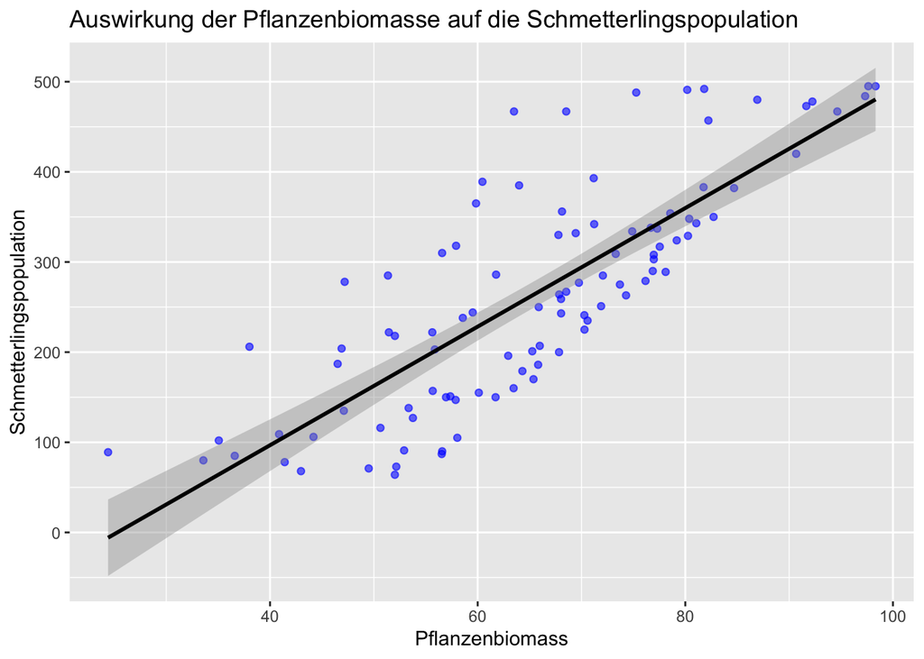

```r
# Visualisierung: Streudiagramm
ggplot(data, aes(x = Pflanzenbiomasse, y = Schmetterlingspopulationen)) +
  geom_point(color = "blue", alpha = 0.6) +
  geom_smooth(method = "lm", col = "black") +
  ggtitle("Auswirkung der Pflanzenbiomasse auf die Schmetterlingspopulation") +
  xlab("Pflanzenbiomass") +
  ylab("Schmetterlingspopulation")
```

## 4.3 Signifikanztest für kategoriale Gruppen: Wilcoxon-Test

### 🧪 Warum ein Wilcoxon-Test?

Wenn wir untersuchen möchten, ob sich zwei **Gruppen** signifikant in Bezug auf eine **numerische Variable** unterscheiden (z.B. ob die **Schmetterlingspopulation** bei **hoher** vs. **niedriger** Biomasse unterschiedlich ist), können wir einen **Wilcoxon-Rangsummentest** verwenden.

- Der Wilcoxon-Test ist ein **nicht-parametrischer Test** – er benötigt keine Normalverteilung der Daten.
- Ideal für **kleinere Stichproben** oder **nicht-normalverteilte Daten**.

### 📊 Visualisierung der Gruppenunterschiede

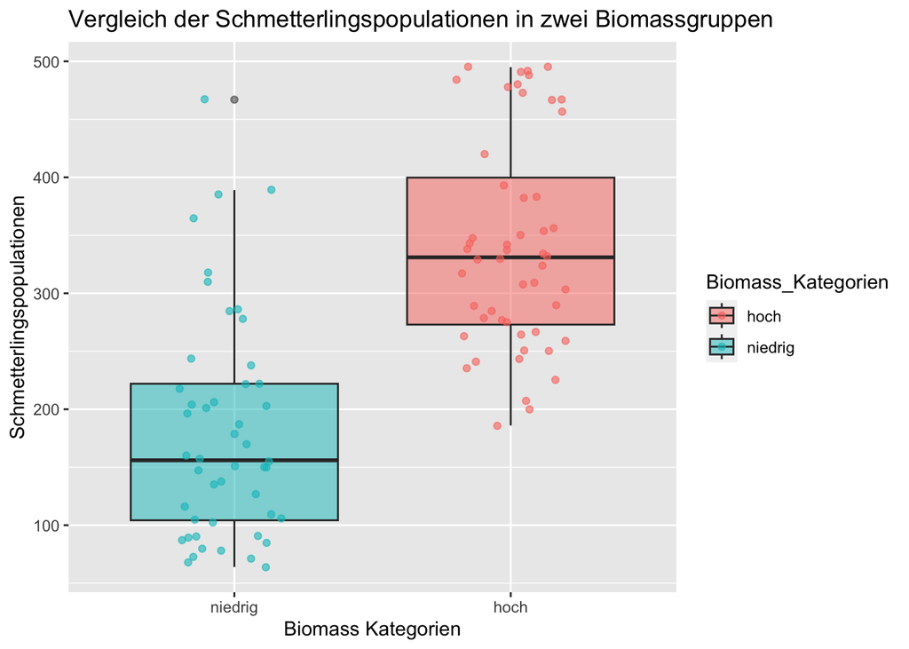

```r
ggplot(data, aes(x = factor(Biomass_Kategorien, levels = c("niedrig","hoch")), y = Schmetterlingspopulationen, fill = Biomass_Kategorien)) +
  geom_boxplot(alpha = 0.5) +
  geom_jitter(aes(color = Biomass_Kategorien), alpha = 0.6, width = 0.2) +
  ggtitle("Vergleich der Schmetterlingspopulationen in zwei Biomassgruppen") +
  xlab("Biomass Kategorien") +
  ylab("Schmetterlingspopulationen")
```

#### 📈 Statistische Aussagen

Ein Boxplot erlaubt folgende Rückschlüsse:

- **Lage**: Zentralwert (Median)
- **Streuung**: Breite der Box (IQR) und Länge der Whiskers
- **Symmetrie oder Schiefe**: Position des Medians innerhalb der Box
- **Ausreißer**: Erkennung extremer Werte
- **Vergleichbarkeit**: Mehrere Boxplots nebeneinander zeigen Unterschiede zwischen Gruppen

### 🛠 Durchführung des Wilcoxon-Tests in R

```r
wilcox_test <- wilcox.test(Schmetterlingspopulationen ~ Biomass_Kategorien, data = data)
print(wilcox_test)
```

```
##
##  Wilcoxon rank sum test with continuity correction
##
## data:  Schmetterlingspopulationen by Biomass_Kategorien
## W = 2217.5, p-value = 2.299e-11
## alternative hypothesis: true location shift is not equal to 0
```

### 🧠 Interpretation des Ergebnisses

- **p-Wert < 0.05** → Es gibt einen signifikanten Unterschied in der Schmetterlingspopulation zwischen den Biomasseklassen.
- **p-Wert > 0.05** → Kein signifikanter Unterschied nachweisbar.

Dieser Test hilft uns, Unterschiede zwischen Gruppen auf einfache und robuste Weise zu erkennen – ohne strenge Verteilungsannahmen!

## 4.4 Wie beeinflusst die Stichprobengröße die statistischen Ergebnisse?

Wir führen eine Regression mit einer **kleinen Stichprobe (N = 10)** durch, um Unterschiede zu beobachten.

```r
small_sample <- data %>% sample_n(10)
small_model <- lm(Schmetterlingspopulationen ~ Pflanzenbiomasse, data = small_sample)

# R²-Werte vergleichen
summary(small_model)
```

```
##
## Call:
## lm(formula = Schmetterlingspopulationen ~ Pflanzenbiomasse, data = small_sample)
##
## Residuals:
##    Min     1Q Median     3Q    Max
## -47.55 -42.32 -27.91  19.39 167.18
##
## Coefficients:
##                  Estimate Std. Error t value Pr(>|t|)
## (Intercept)      -469.797    190.910  -2.461  0.03927 *
## Pflanzenbiomasse   10.503      2.722   3.859  0.00482 **
## ---
## Signif. codes:  0 '***' 0.001 '**' 0.01 '*' 0.05 '.' 0.1 ' ' 1
##
## Residual standard error: 70.58 on 8 degrees of freedom
## Multiple R-squared:  0.6505, Adjusted R-squared:  0.6068
## F-statistic: 14.89 on 1 and 8 DF,  p-value: 0.004818
```

Kleinere Stichproben liefern oft **weniger verlässliche** Schätzungen aufgrund höherer Variabilität.

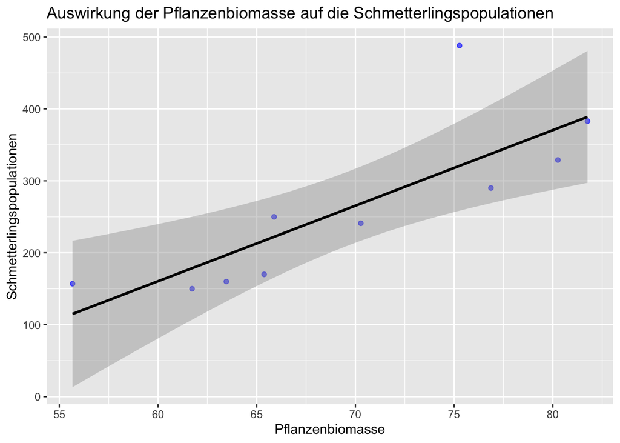

```r
# Visualisierung: Streudiagramm
ggplot(small_sample, aes(x = Pflanzenbiomasse, y = Schmetterlingspopulationen)) +
  geom_point(color = "blue", alpha = 0.6) +
  geom_smooth(method = "lm", col = "black") +
  ggtitle("Auswirkung der Pflanzenbiomasse auf die Schmetterlingspopulationen") +
  xlab("Pflanzenbiomasse") +
  ylab("Schmetterlingspopulationen")
```

# 5. Untersuchung des Zusammenhangs zwischen Biomasseproduktion und Boden‑pH

## 5.1 Nichtlineare Zusammenhänge

Viele Datenbeziehungen sind nichtlinear. Daher ist es wichtig, die Daten immer zu visualisieren, bevor man Annahmen für ein Modell trifft.

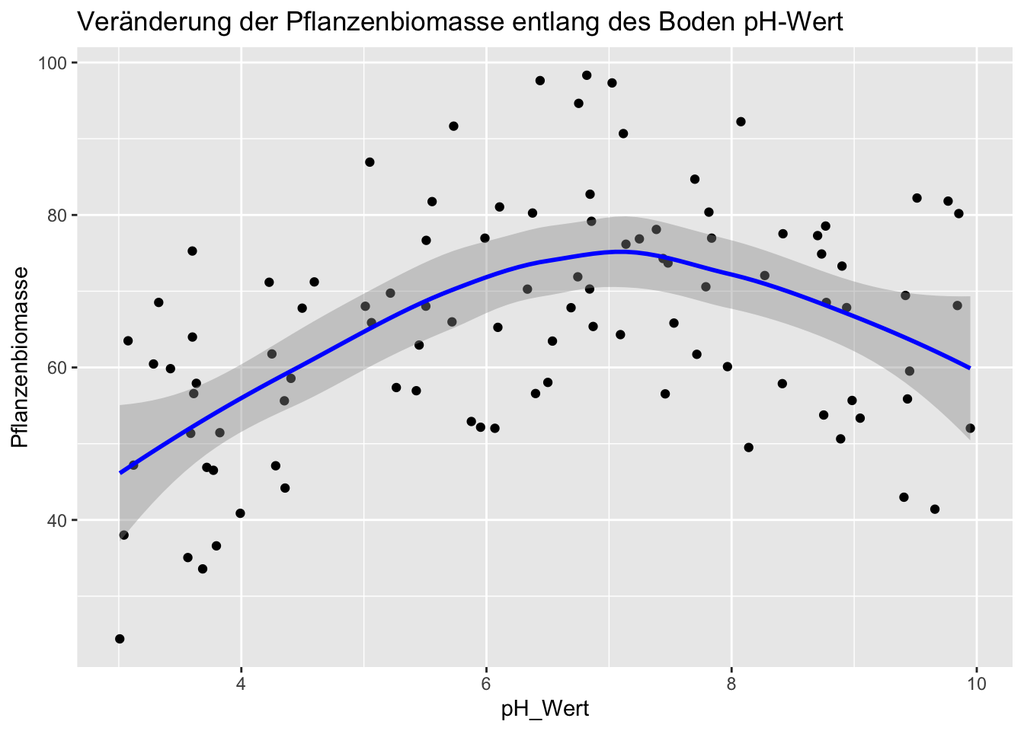

```r
# Streudiagramm für Boden‑pH vs. Biomasse
ggplot(data, aes(x = pH_Wert, y = Pflanzenbiomasse)) +
  geom_point() +
  geom_smooth(method = "loess", col = "blue") +
  ggtitle("Veränderung der Pflanzenbiomasse entlang des Boden pH-Wert")
```

## 5.2 Quadratisches Modell

**(💡 Hinweis: Diese Fähigkeit zur quadratischen Modellierung ist für diesen Kurs nicht erforderlich, aber nützlich für fortgeschrittene ökologische Analysen.)**

Nach der Visualisierung der Daten mit einem Streudiagramm beobachten wir einen gekrümmten Trend zwischen der Biomasseproduktion und dem Boden‑pH-Wert. Ein lineares Modell könnte diesen Zusammenhang nicht genau abbilden. Stattdessen nehmen wir an, dass die Biomasseproduktion in einer quadratischen Beziehung zum Boden‑pH steht.

Um dies zu berücksichtigen, verwenden wir ein quadratisches Regressionsmodell, das das lineare Modell um einen quadrierten Term `(Soil_pH²)` erweitert. Dieser Ansatz ermöglicht es uns, die nichtlineare Beziehung zwischen den Variablen abzubilden.

```r
# Quadratisches Regressionsmodell anpassen, um den Zusammenhang zwischen Boden‑pH und Biomasse zu analysieren
quadratic_model <- lm(Pflanzenbiomasse ~ pH_Wert + I(pH_Wert^2), data = data)

# Zusammenfassung des Modells anzeigen, um Koeffizienten, R²-Wert und p-Werte zu überprüfen
summary(quadratic_model)
```

```
##
## Call:
## lm(formula = Pflanzenbiomasse ~ pH_Wert + I(pH_Wert^2), data = data)
##
## Residuals:
##      Min       1Q   Median       3Q      Max
## -22.0531  -9.7433   0.2093   8.0957  24.9254
##
## Coefficients:
##              Estimate Std. Error t value Pr(>|t|)
## (Intercept)  -14.7373    12.9788  -1.135    0.259
## pH_Wert       24.9239     4.3234   5.765 9.69e-08 ***
## I(pH_Wert^2)  -1.7596     0.3351  -5.252 8.91e-07 ***
## ---
## Signif. codes:  0 '***' 0.001 '**' 0.01 '*' 0.05 '.' 0.1 ' ' 1
##
## Residual standard error: 12.72 on 97 degrees of freedom
## Multiple R-squared:  0.307,  Adjusted R-squared:  0.2927
## F-statistic: 21.48 on 2 and 97 DF,  p-value: 1.891e-08
```

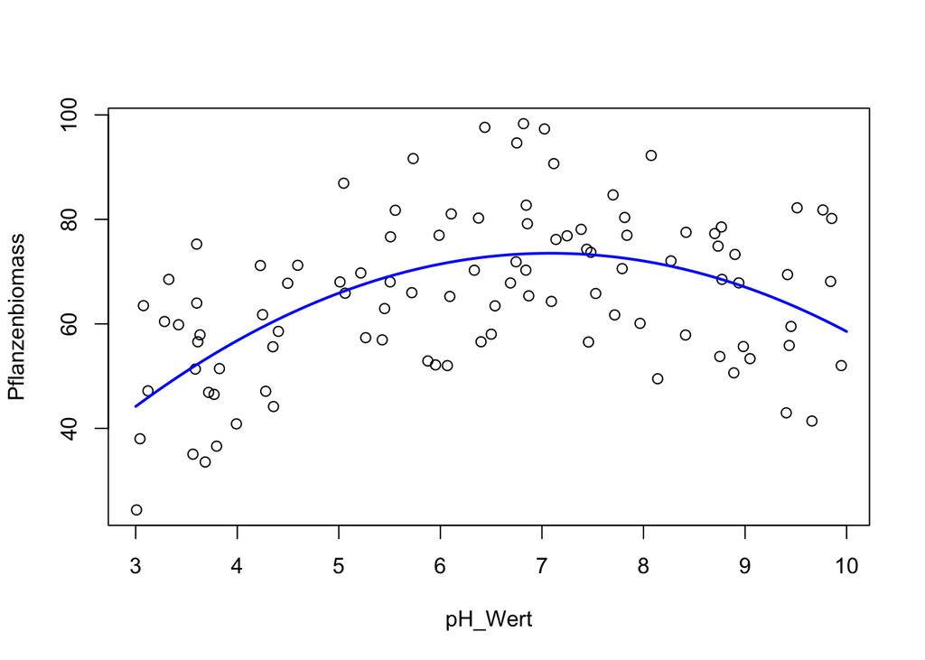

```r
# Vorhergesagte Biomassewerte mithilfe des angepassten quadratischen Modells generieren
predicted_produ <- predict(
  quadratic_model,  # Modell für die Vorhersage
  newdata = data.frame(
    pH_Wert = seq(3,  # Minimaler Boden‑pH-Wert in unserem Bereich
                  10,  # Maximaler Boden‑pH-Wert in unserem Bereich
                  length.out = 1000 # Anzahl der Punkte zur Erzeugung einer glatten Kurve
                  )
  )
)

# Streudiagramm von Boden‑pH vs. Biomasse erstellen, um die tatsächlichen Datenpunkte zu visualisieren
plot(
  data$pH_Wert,  # X-Achse: Boden‑pH-Werte aus unserem Datensatz
  data$Pflanzenbiomasse,  # Y-Achse: Biomassewerte aus unserem Datensatz
  xlab = "pH_Wert",  # Beschriftung der X-Achse
  ylab = "Pflanzenbiomass"  # Beschriftung der Y-Achse
)

# Die vorhergesagte quadratische Kurve (angepasste Werte) zum Diagramm hinzufügen
lines(
  seq(3, 10, length.out = 1000),  # X-Werte für die glatte Kurve
  predicted_produ, # Vorhergesagte Biomassewerte
  col = "blue",  # Linienfarbe
  lwd = 2  # Linienbreite für bessere Sichtbarkeit
)
```

# 6. Korrelation ist nicht gleich Kausalität

## 6.1 Untersuchung des Zusammenhangs zwischen Biomasseproduktion und Sonnenfleckenaktivität

```r
# Korrelationsanalyse durchführen
cor_test_sunspots <- cor.test(data$Sonnenflecken, data$Pflanzenbiomasse)
print(cor_test_sunspots)
```

```
##
##  Pearson's product-moment correlation
##
## data:  data$Sonnenflecken and data$Pflanzenbiomasse
## t = 6.8763, df = 98, p-value = 5.78e-10
## alternative hypothesis: true correlation is not equal to 0
## 95 percent confidence interval:
##  0.4212734 0.6896288
## sample estimates:
##       cor
## 0.5704862
```

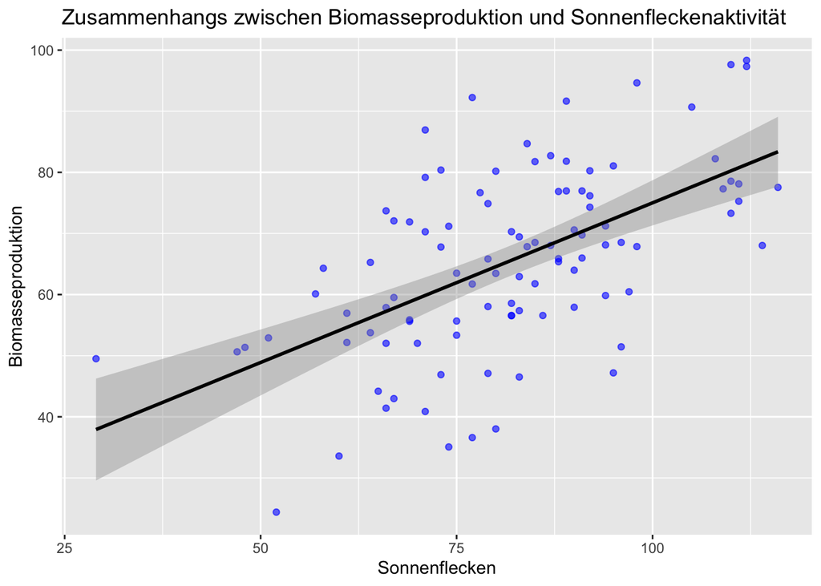

```r
# Visualisierung
ggplot(data, aes(x = Sonnenflecken, y = Pflanzenbiomasse)) +
  geom_point(color = "blue", alpha = 0.6) +
  geom_smooth(method = "lm", col = "black") +
  ggtitle("Zusammenhangs zwischen Biomasseproduktion und Sonnenfleckenaktivität") +
  xlab("Sonnenflecken") +
  ylab("Biomasseproduktion")
```

Auch wenn die Korrelation statistisch signifikant ist, **bedeutet das noch lange nicht, dass ein kausaler Zusammenhang besteht**.

## 6.2 Warum handelt es sich um eine Scheinkorrelation?

# 7. Fazit

- Wir haben eine **signifikante Korrelation** zwischen der **Schmetterlingspopulation und der Biomasseproduktion** festgestellt.
- Der Zusammenhang zwischen Boden‑pH und Biomasse könnte **nichtlinear** sein.
- Eine **statistische Korrelation bedeutet nicht automatisch Kausalität** (z.B. Sonnenflecken und Biomasse).

# 8. Nächste Schritte

- **Weitere Prädiktoren untersuchen**, die die Schmetterlingspopulation beeinflussen.
- **Fortgeschrittene statistische Modelle anwenden** (z.B. multiple Regression, gemischte Modelle).